# Final Report for Intro to Data Science

# Team Members

- Madison Yonash

# Introduction

I use a daily journaling app called “Daylio” to track my mood and activities that I have done throughout the day. In 2019, I made the accomplishment of tracking this every single day of the year (with some days having multiple entries). I’ve always been interested in the data and visualizations that the app has to offer, from creating a color scale of my mood for a particular month to a weekly recap of what happened. However, not all of my questions could be answered by the app itself. I saw that I could download the data as a .csv file, and from there, my exploration of the data began.

The app itself is relatively straightforward: you click one of the “moods” you create (mine included names like “meh”, “not good but feel like it should be”, etc) (which are inherently factors, even if the app doesn’t make it seem like it at first glance!), select activities/traits that apply to your day, and write notes if you would like. For the sake of this report, I omitted the notes I had and created a `mood_scale` that is a numerical representation of the factors (for ex, multiple moods had the equivalent of a 4/5 so I took this step for my own usability purposes). before uploading the csv file to GitHub.

As a female in her 20s, it is no surprise that I am familiar with astrology. You may have heard the term that X is happening because [“Mercury is in Retrograde.”](https://www.cnn.com/cnn-underscored/health-fitness/mercury-retrograde-2022) While I’m by no means an expert on astrological occurrences, I thought it would be fun to do some additional exploration to see if this had any correlation with my mood. I also want to use other data sets with factors that may affect my mood. I found a [super cool GitHub Repo](https://github.com/Paris778/Retrograde-Mercury-Dates-Dataset-1990-2020) that relates to this topic.

# *Tidying* Up the Data

Since the data initially came from all years that I have used the app, it is important to make the data tidy and easier to work with.

Load necessary packages:

```r
library(tidyverse)
library(lubridate) #date and time
```

## Working with the Dailyo Data

Import data, which can be found [here](https://github.com/madiyonash/DS_Final_Project/blob/master/data/clean_report.csv):

```r
clean_report <- read_csv("C:/Users/madis/Documents/intro to ds/final_project/DS_Final_Project/data/clean_report.csv")
```

To analyze the data from 2019, we must filter the dataset for entries taken during that year. The use of the `lubridate` package makes this easy:

```r
report_2019 <- clean_report %>%
  filter(between(date, as.Date("2019-01-01"), as.Date("2019-12-31")))
```

If you take a glance at the `activities` column, you may notice that the observations have a varying number of activities. Here is a sample of some of the observations:

```r
report_2019 %>%
  select(activities) %>%
  sample_n(5)
```

| activities |
| --- |
| friends \| eat out \| cfa \| date \| homework \| bujo \| test \| hw date |
| 50 pushups \| relax \| travel \| shopping \| date \| homework \| game/meet \| weightlifting \| gym |
| relax \| eat out \| homework \| game/meet \| soccer |
| facetime \| homework \| cleaning |
| relax \| homework \| cleaning |

To make it easier to work with this data, we can separate the activities so that each activity is contained within its own observation:

```r
report_2019_sep <- report_2019 %>%
  separate_rows(activities, sep = "\\|")

report_2019_sep$activities <- trimws(report_2019_sep$activities, which = c("both"))
```

Additionally, we can create an additional column that summarizes the average the mood per day. This will let us compare the rating of any particular day in 2019 with other factors.

```r
report_2019_day <- report_2019 %>%
  group_by(date) %>%
  summarize(ave_mood = mean(mood_scale, na.rm=T))
```

## Mercury in Retrograde

We will additionally be using a dataset that deals with mercury in retrograde. The original file can be found [here](https://github.com/Paris778/Retrograde-Mercury-Dates-Dataset-1990-2020)

```r
mercury_in_retrograde <- read_csv("C:/Users/madis/Documents/intro to ds/final_project/DS_Final_Project/data/1990_2020_mercury_retrograde_dataset.csv")
```

Once again, let’s limit this to the year 2019.

```r
mercury_in_retrograde <- mercury_in_retrograde %>%
  filter(between(DATE, as.Date("2019-01-01"), as.Date("2019-12-31")))
```

# Data Description

Now that the data is prepared, let’s see what it shows us.

## Dailyo Data

In the Tidying Up the Data section, we created a few dataframes from our initial download from the Dailyo app called `clean_report`.

The one we can most relevantly go back to is the `report_2019`, which contains all entries for the year 2019 (which is the focus of this report).

The features of the original 2019 dataset include:

- date | date format (yyyy/mm/dd)
- mood | character
- activities | character
- mood scale | number

```r
glimpse(report_2019)
```

```
Rows: 393
Columns: 4
$ date       <date> 2019-12-31, 2019-12-30, 2019-12-29, 2019-12-28, 2019-12-27, 2019-12-26, 2019-12-~
$ mood       <chr> "enamorada", "enamorada", "meh", "meh", "good", "rad", "meh", "bad", "meh", "good~
$ activities <chr> "relax | eat out | family | shopping | date | quality time | weightlifting | gym ~
$ mood_scale <dbl> 5, 5, 3, 3, 4, 5, 3, 2, 3, 4, 2, 1, 4, 5, 5, 4, 3, 4, 2, 1, 3, 3, 4, 4, 4, 4, 3, ~
```

Let’s see what a few of my days looked like:

```r
report_2019 %>%
  sample_n(10)
```

| date | mood | activities | mood_scale |
| --- | --- | --- | --- |
| 2019-09-29 | good | relax \| family \| date \| homework \| bujo \| cleaning | 4 |
| 2019-03-17 | rad | relax \| friends \| travel \| eat out \| bujo | 5 |
| 2019-01-31 | meh | relax \| homework \| bujo | 3 |
| 2019-12-10 | meh | 50 pushups \| friends \| travel \| eat out \| homework \| test \| game/meet \| soccer \| gym \| sick | 3 |
| 2019-07-28 | bad | eat out \| family \| work \| nap | 2 |
| 2019-12-13 | good | NA | 4 |
| 2019-02-27 | good | homework \| nap | 4 |
| 2019-05-25 | good | relax \| friends \| travel \| eat out \| volunteering | 4 |
| 2019-10-12 | enamorada | relax \| friends \| travel \| eat out \| date \| quality time \| homework \| nap | 5 |
| 2019-04-05 | rad | relax \| friends \| travel \| eat out \| bujo \| volunteering \| bleeding | 5 |

From there, for my own usability purposes, I created two additional dataframes from this report of all 2019 entries. These are `report_2019_sep` and `report_2019_day`

In the `report_2019_sep` data, we have a version of the original dataset, with each observation holding a separate activity category. This was important to do because, as seen earlier, some observations had multiple activities while some had none at all.

```r
glimpse(report_2019_sep)
```

```
Rows: 2,107
Columns: 4
$ date       <date> 2019-12-31, 2019-12-31, 2019-12-31, 2019-12-31, 2019-12-31, 2019-12-31, 2019-12-~
$ mood       <chr> "enamorada", "enamorada", "enamorada", "enamorada", "enamorada", "enamorada", "en~
$ activities <chr> "relax", "eat out", "family", "shopping", "date", "quality time", "weightlifting"~
$ mood_scale <dbl> 5, 5, 5, 5, 5, 5, 5, 5, 5, 5, 5, 5, 5, 5, 5, 5, 5, 5, 5, 5, 3, 3, 3, 3, 3, 3, 3, ~
```

```r
#print sample of this report
report_2019_sep %>%
  sample_n(5)
```

| date | mood | activities | mood_scale |
| --- | --- | --- | --- |
| 2019-03-21 | good | relax | 4 |
| 2019-08-23 | rad | eat out | 5 |
| 2019-12-06 | rad | weightlifting | 5 |
| 2019-12-02 | bad | bujo | 2 |
| 2019-09-18 | bad | homework | 2 |

This will be helpful when looking at possible correlation related to the activities I have done during different days.

```r
glimpse(report_2019_day)
```

```
Rows: 365
Columns: 2
$ date     <date> 2019-01-01, 2019-01-02, 2019-01-03, 2019-01-04, 2019-01-05, 2019-01-06, 2019-01-07~
$ ave_mood <dbl> 5, 4, 4, 5, 3, 2, 3, 3, 3, 4, 4, 4, 3, 4, 3, 4, 4, 5, 4, 5, 4, 4, 3, 2, 5, 4, 3, 3,~
```

Let’s take a look at it:

```r
#print sample of this report
report_2019_day %>%
  sample_n(5)
```

| date | ave_mood |
| --- | --- |
| 2019-07-01 | 4 |
| 2019-06-16 | 5 |
| 2019-01-23 | 3 |
| 2019-05-17 | 4 |
| 2019-07-23 | 4 |

This dataframe will be helpful in completing analysis related to the year as a whole. From here, we can look at trends in average daily mood, compare things on a day by day basis (which would be more difficult with some days having multiple entries or differing numbers of activities).

## Mercury in Retrograde Data

The Mercury in Retrograde data comes from [this Github Repo](https://github.com/Paris778/Retrograde-Mercury-Dates-Dataset-1990-2020).

Per the Repo: “The present dataset consists of two features those being:

- DATE | date format (yyyy/mm/dd)
- isRetrograde | boolean (0 or 1) isRetrograde has a value of 1 (one) when mercury was in retrograde during the respective date and 0 (zero) when it was following a normal course.”

```r
glimpse(mercury_in_retrograde)
```

```
Rows: 365
Columns: 2
$ DATE         <date> 2019-01-01, 2019-01-02, 2019-01-03, 2019-01-04, 2019-01-05, 2019-01-06, 2019-0~
$ isRetrograde <dbl> 0, 0, 0, 0, 0, 0, 0, 0, 0, 0, 0, 0, 0, 0, 0, 0, 0, 0, 0, 0, 0, 0, 0, 0, 0, 0, 0~
```

The original GitHub Repo also provided a photo of a graphical representation of one of the years (2018) of the data:

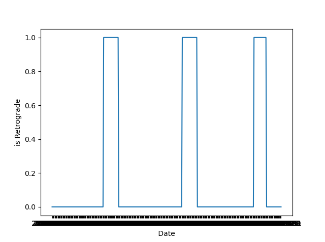

# Exploratory Data Analysis

Before beginning our analysis, let’s print a summary of the `report_2019` dataset:

```r
summary(report_2019)
```

```
      date                mood            activities          mood_scale
 Min.   :2019-01-01   Length:393         Length:393         Min.   :1.000
 1st Qu.:2019-04-07   Class :character   Class :character   1st Qu.:3.000
 Median :2019-07-12   Mode  :character   Mode  :character   Median :4.000
 Mean   :2019-07-07                                         Mean   :3.743
 3rd Qu.:2019-10-06                                         3rd Qu.:4.000
 Max.   :2019-12-31                                         Max.   :5.000
```

This shows that, despite our 365 days in a year, we have 393 observations. It is also interesting to note the mean of the mood scale: from here, we see that in 2019 it was a 3.743/5. Not a bad number! Note that this is averaging all 393 entries and is not finding the mean based on a daily average.

## Univariate Data Analysis

This section focuses on looking into the mood scale and activities of the reports individually.

### Mood

First, let’s see how my feelings stacked up by visualizing the distribution of individual entries of my moods.

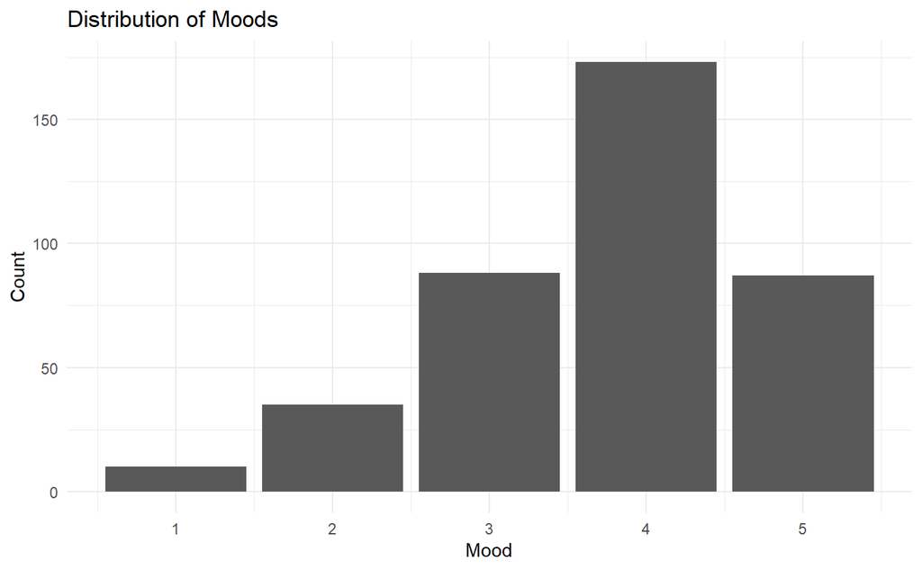

```r
report_2019 %>%
  ggplot() +
  geom_bar(mapping = aes(mood_scale)) +
  labs(title = "Distribution of Moods", x = "Mood", y = "Count") +
  theme_minimal()
```

We can also compare this to the distribution of the daily average:

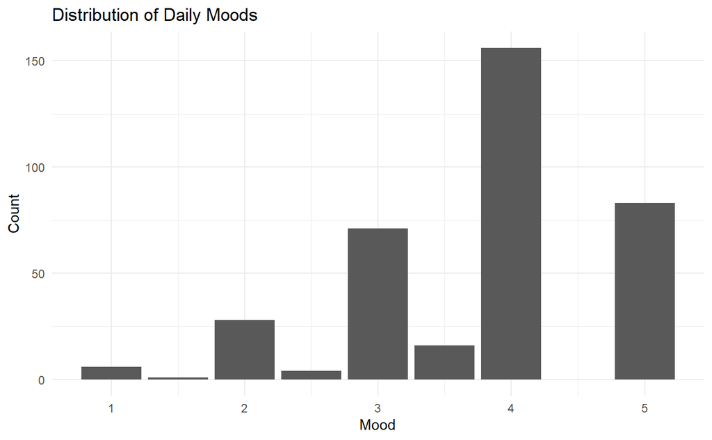

```r
report_2019_day %>%
  ggplot() +
  geom_bar(mapping = aes(ave_mood)) +
  labs(title = "Distribution of Daily Moods", x = "Mood", y = "Count") +
  theme_minimal()
```

Note that, upon finding the distribution of the daily average, most entries were an integer, however some days had scores that fell between the ranges (ie: there was an entry that was 4/5 in the morning and one that was 3/5 in the evening, therefore the daily mood was 3.5). The number of these is significantly less than the integer entries, however. There are also no entries that had the mood of 4.5.

```r
report_2019_day %>%
  summarize(avg_daily_mood = mean(ave_mood))
```

| avg_daily_mood |
| --- |
| 3.784932 |

The average daily mood is also slightly higher than the average mood of all entries.

### Activities

Next, let’s see what kinds of things I did over the year.

```r
#find how frequently i did different things
report_2019_sep %>%
  group_by(activities) %>%
  summarize(count = n()) %>%
  arrange(desc(count))
```

| activities | count |
| --- | --- |
| homework | 226 |
| relax | 196 |
| friends | 189 |
| eat out | 187 |
| date | 150 |
| travel | 116 |
| cleaning | 113 |
| nap | 93 |
| bujo | 86 |
| family | 77 |

[output cut: 20 more lines]

… It’s a bit sad that my most frequent activity was doing homework …

Moving on, let’s create a visualization of the frequency I completed different activities:

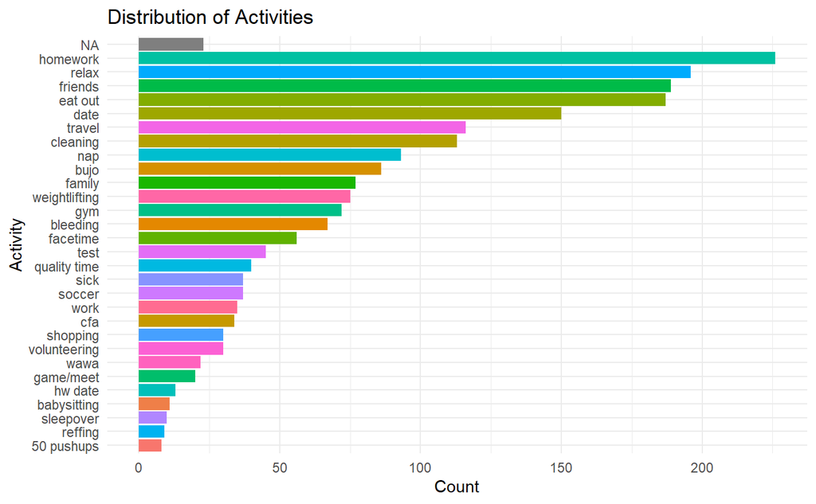

```r
report_2019_sep %>%
  ggplot() +
  geom_bar(mapping = aes(fct_rev(fct_infreq(activities)),
                         fill = activities)) +
  coord_flip() +
  theme_minimal() +
  guides(fill="none") +
  labs(title = "Distribution of Activities", x = "Activity", y = "Count")
```

## Multivariate Data Analysis

### Changes over the Year

First, let’s try and graph my average daily mood over the course of the year.

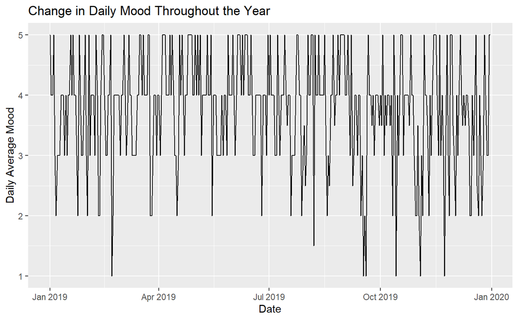

```r
report_2019_day %>%
  ggplot() +
  geom_line(mapping = aes(x = date, y = ave_mood)) +
  labs(title = "Change in Daily Mood Throughout the Year", y = "Daily Average Mood",
       x = "Date")
```

Wow, that’s turbulent! This isn’t super insightful, so further breaking down the data may help us learn more about it.

### Montly Averages

Let’s see how my mood during the different months in the year compare.

```r
# before we go into looking at the months, create a new dataframe that is easier to work with
# make additional columns for month and day
report_2019_months <- report_2019_day %>%
  mutate(day = format(report_2019_day$date, "%d")) %>%
  mutate(month = month(ymd(date), label = T)) %>%
  select(ave_mood, month, day)
report_2019_months$day <- as.numeric(report_2019_months$day)
# find average mood by month as well as variation
report_2019_months %>%
  group_by(month) %>%
  summarize(avg_montly_mood = mean(ave_mood), variation = var(ave_mood))
```

| month | avg_montly_mood | variation |
| --- | --- | --- |
| Jan | 3.741935 | 0.7311828 |
| Feb | 3.607143 | 1.1362434 |
| Mar | 3.854839 | 0.7198925 |
| Apr | 4.133333 | 0.6712644 |
| May | 3.903226 | 0.5569892 |
| Jun | 4.133333 | 0.6022989 |
| Jul | 3.725806 | 0.6806452 |
| Aug | 4.048387 | 0.8892473 |
| Sep | 3.550000 | 1.0922414 |
| Oct | 3.677419 | 0.9258065 |

[output cut: 2 more lines]

Here we can see the average mood for the month as a whole, as well as the variation for each month.

To visualize this:

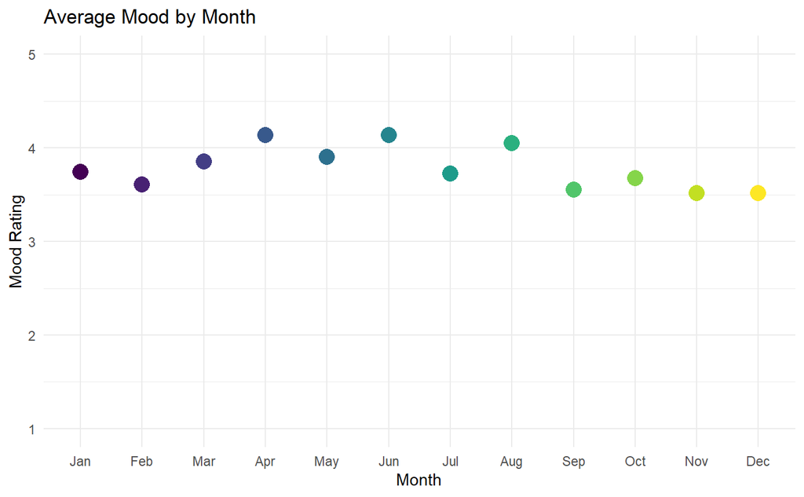

```r
report_2019_months %>%
  group_by(month) %>%
  summarize(avg_montly_mood = mean(ave_mood), variation = var(ave_mood)) %>%
  ggplot() +
  geom_point(aes(
    x = month,
    y = avg_montly_mood,
    size = 3,
    color = month)) +
  ylim(1,5) +
    labs(title = "Average Mood by Month",
         y = "Mood Rating",
         x = "Month") +
  guides(size="none", color = "none") +
  theme_minimal()
```

This gives us an idea of how I was doing, by the mean mood, month to month. It was relatively consistent, with the end of the year being slightly lower. A possible explanation for this was the start of senior year of high school, complete with everything from college applications to International Baccalaureate exams!

### Mood Over Each Month

This, however, does not show us how I was doing within the month itself. Another visualization that we can create could be to show how my mood changed from month to month, comparing the actual changes within the month rather than the mean for the month as a whole.

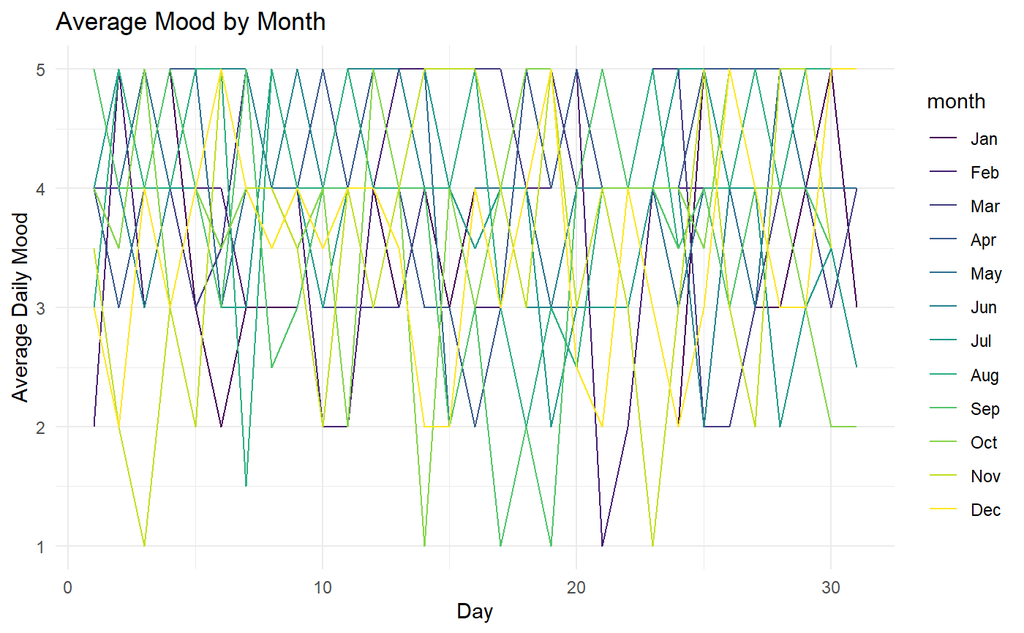

```r
#visualize data
report_2019_months %>%
  ggplot( aes(x=day, y=ave_mood, group=month, color=month)) +
    geom_line() +
  ggtitle("Average Mood by Month") +
  labs(x = "Day", y ="Average Daily Mood") +
  theme_minimal()
```

That’s pretty ugly. Since there are so many lines on one chart, it is difficult to compare the trends within each month. Let’s try again:

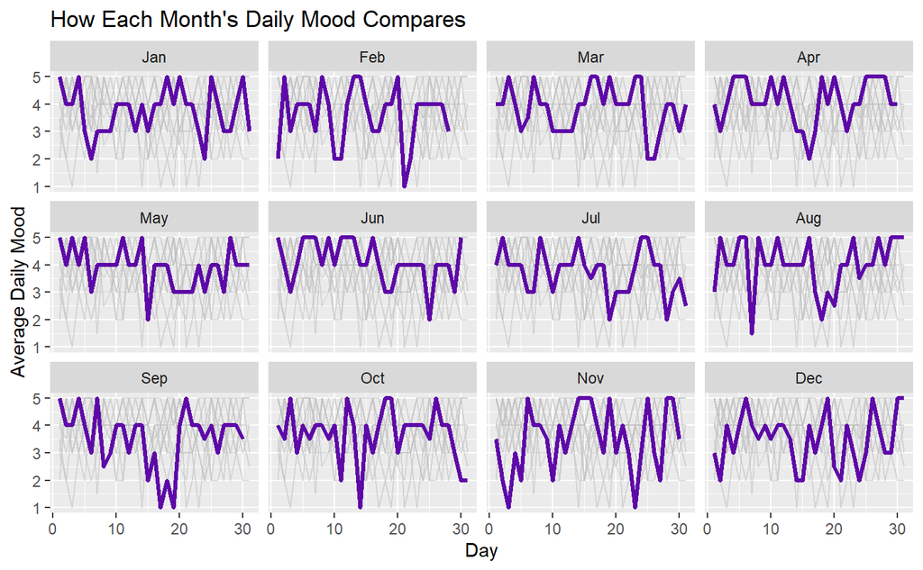

```r
# try again
tmp <- report_2019_months %>%
  mutate(month2 = month)

tmp %>%
  ggplot( aes(x=day, y=ave_mood)) +
    geom_line( data=tmp %>% dplyr::select(-month), aes(group=month2), color="grey", size=0.5, alpha=0.5) +
    geom_line( aes(color=month), color="#5e08a8", size=1.2 )+
    labs(title = "How Each Month's Daily Mood Compares",
         x = "Day",
         y ="Average Daily Mood") +
    facet_wrap(~month)
```

I think that’s pretty neat! Here, we can see how the average daily mood changed throughout the course of each of the months. Some months were a little more varied than others.

### Mood and Activities

To see how the average daily mood was affected by individual activities, the `report_2019_sep` can be joined with the `report_2019_day` dataframe.

```r
# join average mood to report_2019_sep
report_2019_activities <- left_join(report_2019_sep, report_2019_day, by = "date")
```

How does the overall mood of the day compare to the activities done? To investigate this, we can find the mean mood for all days an activity is done.

```r
report_2019_activities %>%
  group_by(activities) %>%
  summarize(avg = mean(mood_scale)) %>%
  arrange(desc(avg))
```

| activities | avg |
| --- | --- |
| wawa | 4.590909 |
| quality time | 4.425000 |
| sleepover | 4.400000 |
| travel | 4.206897 |
| friends | 4.100529 |
| relax | 4.086735 |
| eat out | 4.058824 |
| date | 4.053333 |
| bleeding | 4.014925 |
| game/meet | 3.950000 |

[output cut: 20 more lines]

*For context, I used to go to Wawa to hang out with my friends for hours and get food/drinks while we were there. Quality time indicates that I spent time with my boyfriend*

```r
head(report_2019_activities %>%
  group_by(activities) %>%
  summarize(avg = mean(mood_scale)) %>%
  arrange(desc(avg)))
```

| activities | avg |
| --- | --- |
| wawa | 4.590909 |
| quality time | 4.425000 |
| sleepover | 4.400000 |
| travel | 4.206897 |
| friends | 4.100529 |
| relax | 4.086735 |

```r
tail(report_2019_activities %>%
  group_by(activities) %>%
  summarize(avg = mean(mood_scale)) %>%
  arrange(desc(avg)))
```

| activities | avg |
| --- | --- |
| sick | 3.567568 |
| cfa | 3.558824 |
| babysitting | 3.545455 |
| soccer | 3.459459 |
| hw date | 3.384615 |
| NA | 2.739130 |

Overall, it makes sense that activities that relate to hanging out with friends and loved ones correlated with a higher average mood, while things like sick and babysitting ranked lower.

Let’s see this in a visualization!

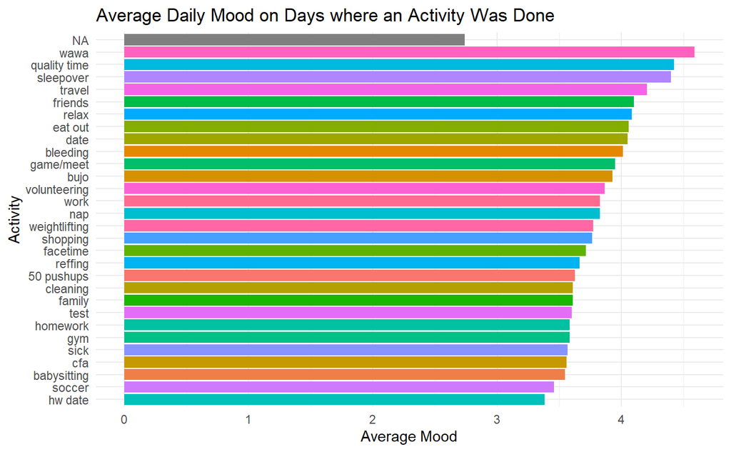

```r
report_2019_activities %>%
  group_by(activities) %>%
  summarize(avg = mean(mood_scale)) %>%
  ggplot() +
  geom_col(aes(x = fct_reorder(activities, avg),
               y = avg,
               fill = activities)) +
  theme_minimal() +
  labs(title = "Average Daily Mood on Days where an Activity Was Done",
       x = "Activity",
       y = "Average Mood") +
  guides(fill="none") +
  coord_flip()
```

Another visualization that we can do that relates to this aspect of the investigation is the *distribution* of mood for each activity. Let’s make it:

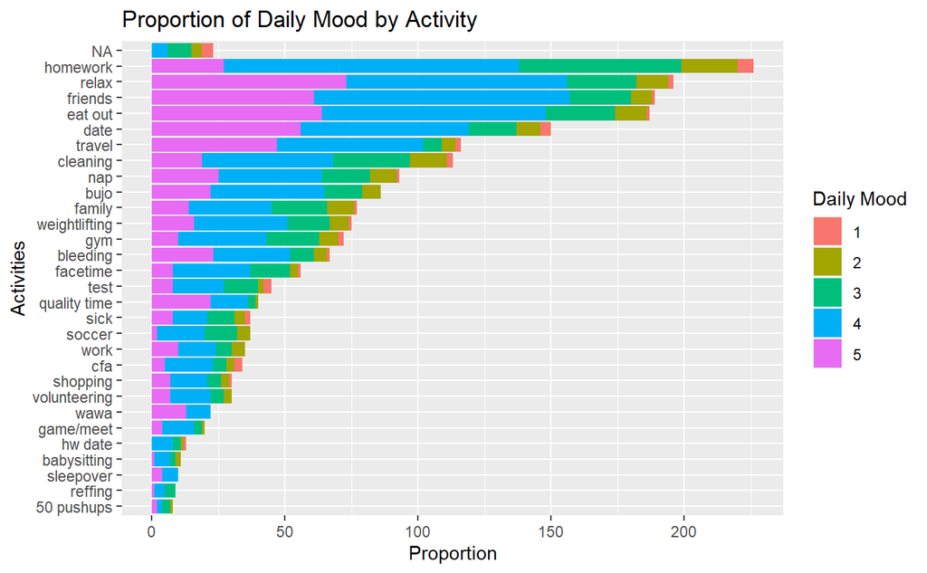

```r
# make mood scale temporarily a character
temp <- report_2019_activities %>%
  mutate(mood_scale = as.character(report_2019_activities$mood_scale))

# create visualization
temp %>%
  ggplot(aes(x = fct_rev(fct_infreq(activities)),
             fill = mood_scale)) +
  geom_bar(position = "stack") +
  labs(y = "Proportion",
       x = "Activities",
       title = "Proportion of Daily Mood by Activity",
       fill = "Daily Mood") +
  coord_flip()
```

This provides some additional insight to the previous visualization of the average daily mood. For example, Wawa has the highest average daily mood associated with it, but there are significantly less observations of this activity than there are relax, for example.

## Research Questions

Now that we have completed some exploratory data analysis, we can answer some questions about the data.

### How was my mood during mercury retrograde?

This is the fun one that we’ve been waiting for. First, I will join the mercury dataset to the `report_2019_day` set.

```r
# join the mercury dataset to the report_2019_day set
retrograde_mood <- left_join(report_2019_day, mercury_in_retrograde, by = c("date" = "DATE"))
retrograde_mood <- left_join(retrograde_mood, report_2019, by =  "date")
```

Find the mean mood for when `isRetrograde` is `TRUE`.

```r
#find normal mood and variation of all entries
retrograde_mood %>%
    summarize(avg_mood = mean(ave_mood), variation = var(ave_mood))
```

| avg_mood | variation |
| --- | --- |
| 3.743003 | 0.8789369 |

```r
#find mood and variation of all entries when isRetrograde is TRUE
retrograde_mood %>%
  filter(isRetrograde == T) %>%
  summarize(avg_mood_r = mean(ave_mood), variation_mood_r = var(ave_mood))
```

| avg_mood_r | variation_mood_r |
| --- | --- |
| 3.638889 | 0.9381847 |

As we see, the mean mood is slightly lower (3.63) when mercury is in retrograde. Additionally, my mood variation was higher (.94) when mercury was in retrograde. Considering one of the features of mercury retrograde you hear about most is that it makes you feel all over the place, this seems to makes sense!

The question that naturally comes up next is, what happened during those weeks? Let’s find out:

```r
retrograde_mood %>%
  filter(isRetrograde == T)
```

| date | ave_mood | isRetrograde | mood | activities | mood_scale |
| --- | --- | --- | --- | --- | --- |
| 2019-03-07 | 5.0 | 1 | rad | relax \| friends \| travel \| eat out \| facetime \| homework | 5 |
| 2019-03-08 | 4.0 | 1 | good | relax \| friends \| eat out \| facetime \| homework | 4 |
| 2019-03-09 | 4.0 | 1 | good | relax \| friends \| travel \| eat out \| homework \| reffing | 4 |
| 2019-03-10 | 3.0 | 1 | stressed | friends \| eat out \| facetime \| homework \| reffing | 3 |
| 2019-03-11 | 3.0 | 1 | stressed | friends \| homework \| soccer \| cleaning | 3 |
| 2019-03-12 | 3.0 | 1 | stressed | relax \| friends \| eat out \| facetime \| homework \| soccer \| bleeding | 3 |
| 2019-03-13 | 3.0 | 1 | stressed | facetime \| homework \| test | 3 |
| 2019-03-14 | 4.0 | 1 | good | relax \| friends \| eat out \| homework \| bujo \| nap | 4 |
| 2019-03-15 | 4.0 | 1 | good | relax \| friends \| facetime \| volunteering \| nap | 4 |
| 2019-03-16 | 5.0 | 1 | rad | relax \| friends \| travel \| eat out \| bujo \| nap | 5 |

[output cut: 62 more lines]

We can also visualize each of these retrogrades:

```r
# create col we can use for factors
retrograde_mood <- retrograde_mood %>%
  mutate(week = 0)

retrograde_mood$week <- ifelse(between(retrograde_mood$date, as.Date("2019-03-07"), as.Date("2019-03-29")),
1,
retrograde_mood$week)

retrograde_mood$week <- ifelse(between(retrograde_mood$date, as.Date("2019-07-09"), as.Date("2019-08-01")),
2,
retrograde_mood$week)

retrograde_mood$week <- ifelse(between(retrograde_mood$date, as.Date("2019-11-02"), as.Date("2019-11-21")),
3,
retrograde_mood$week)

#create a dataframe that only contains the retrograde weeks
retrograde_weeks <- retrograde_mood %>%
  filter(week != 0)
```

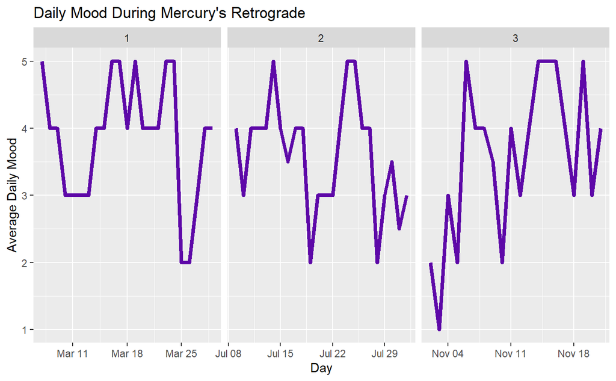

```r
retrograde_weeks %>%
  ggplot( aes(x=date, y=ave_mood)) +
    geom_line( aes(color=name), color="#5e08a8", size=1.5 ) +
    labs(title = "Daily Mood During Mercury's Retrograde",
         x = "Day",
         y ="Average Daily Mood") +
    facet_wrap(~week, scales = "free_x")
```

I will note, I knew very little about astrology, and nothing about Mercury being in Retrograde in 2019. Do I believe that Mercury caused my emotions to be so turbulent? I can’t say so, but it is interesting to look at.

### How did my mood tend to change on a day-to-day basis?

Were there any trends in the data over the course of the week? Was I happier on weekends or weekdays? Let’s look into this!

```r
# you may notice, this process is similar to that of displaying the average mood per month
# before we go into looking at the days, create a new dataframe that is easier to work with
# make additional column for weekday

report_2019_weeks <- report_2019 %>%
  mutate(weekday = wday(date, label = T))
```

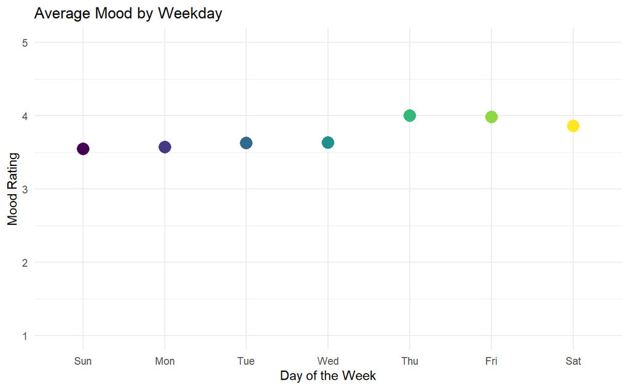

```r
report_2019_weeks %>%
  group_by(weekday) %>%
  summarize(avg_daily_mood = mean(mood_scale), variation = var(mood_scale)) %>%
  ggplot() +
  geom_point(aes(
    x = weekday,
    y = avg_daily_mood,
    size = 3,
    color = weekday)) +
  ylim(1,5) +
    labs(title = "Average Mood by Weekday",
         y = "Mood Rating",
         x = "Day of the Week") +
  guides(size="none", color = "none") +
  theme_minimal()
```

### Does the school year affect the frequency of activities performed?

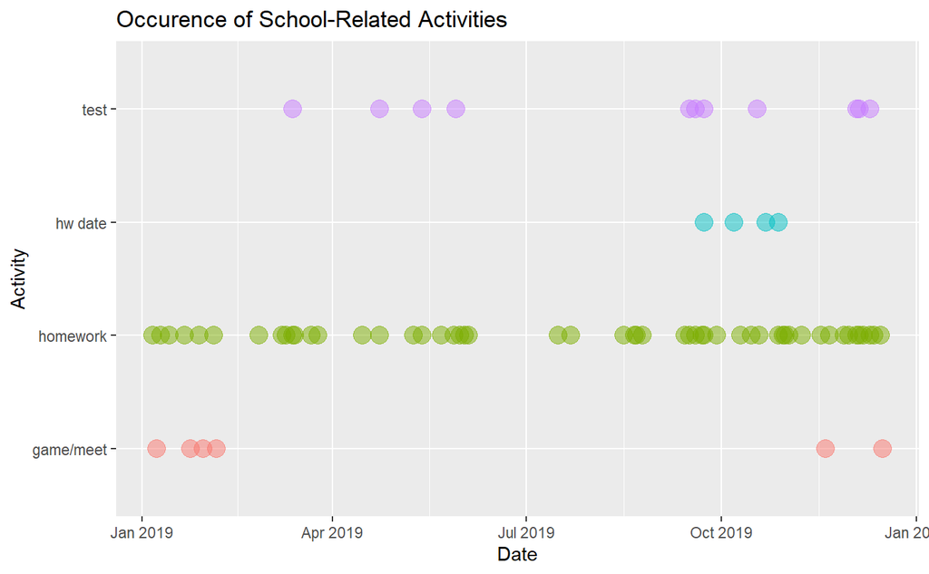

```r
report_2019_activities %>%
  filter(activities == c("homework",
                         "test",
                         "hw date",
                         "game/meet"
                         )) %>%
  ggplot() +
  geom_point(aes(x = date, y = activities, color = activities, size = 3), alpha = .5) +
  guides(size="none", color = "none") +
  labs(title = "Occurence of School-Related Activities",
         y = "Activity",
         x = "Date")
```

Here, we see a heavier distribution for these school-related activities during the academic year, with few to no entries of them during the summer. This falls in line with what we expect to see of this chart.

# Conclusion

This exploration of my own mood data was both interesting and insightful. I was thoroughly engaged in seeing the variation of the distribution of activities and how these varied depending on what scope we viewed the data. It was also interesting to see how the mood averages changes, whether it was viewed at the daily, weekly, monthly, or yearly level. At the practical level, this investigation challenged me to use the tools we have learned in class and adapt them to meet the needs of our projects. From combining conditional statements with dataframes to improving visualizations with ggplot2, this project covered a large scope of the content and made useful learning the transition from basic useage to application. I found myself being familiar with the steps necessary and understanding the concepts that were needed to manipulate data. Even before writing the code, I noticed I was able to think of what I needed to do. For example, when creating data visualizations, I made mental notes that I would have to `mutate` new columns in order to create facets for better visualization, and it then became the task of applying the syntax that we learned in the correct manner. Knowing the concepts that I was trying to apply and what I wanted to accomplish made this task much easier and streamlined the process of creating summaries and visualizations. If I were to continue this project with further investigation, there are a lot more factors that could be considered for exploratory data analysis. One thing that would be interesting to investigate would be what *combinations* of activities led to the highest average mood. In this investigation, we looked into what the mean mood was associated with each activity, but I would be curious to see if certain combinations led themselves to be better or worse. For example, was my day better when I went to the gym and ate out, or went to the gym and hung out with my friends? Additionally, if I continued gathering this data, it would be cool to see how things changed over the years and if there were any trends from certain months year to year or quarters.